# Project3: Loan Data From Prosper

Allan Jacobs

03/30/2015

# Univariate Plots

The setup requires the library boot. If you do not have this library, please run install.packages(‘boot’).

### Structure

There are a lot of variables with which to look at loans and their history. The read.csv function read in some of the columns as categorical data types that should have been character or logical data types. Five columns that should have Date type required programmatic conversions. The computation of ActualYield, a focus of the analyses made here, makes use of ClosedDate and LoanOriginationDate.

```
## 'data.frame':    113937 obs. of  87 variables:
##  $ ListingKey                         : chr  "1021339766868145413AB3B" "10273602499503308B223C1" "0EE9337825851032864889A" "0EF5356002482715299901A" ...
##  $ ListingNumber                      : int  193129 1209647 81716 658116 909464 1074836 750899 768193 1023355 1023355 ...
##  $ ListingCreationDate                : POSIXlt, format: "2007-08-26 19:09:29" "2014-02-27 08:28:07" ...
##  $ CreditGrade                        : Factor w/ 9 levels "NC","HR","E",..: 5 9 2 9 9 9 9 9 9 9 ...
##  $ Term                               : int  36 36 36 36 36 60 36 36 36 36 ...
##  $ LoanStatus                         : Factor w/ 12 levels "Defaulted","Chargedoff",..: 11 9 11 9 9 9 9 9 9 9 ...
##  $ ClosedDate                         : POSIXlt, format: "2009-08-14" NA ...
##  $ BorrowerAPR                        : num  0.165 0.12 0.283 0.125 0.246 ...
##  $ BorrowerRate                       : num  0.158 0.092 0.275 0.0974 0.2085 ...
##  $ LenderYield                        : num  0.138 0.082 0.24 0.0874 0.1985 ...
##  $ EstimatedEffectiveYield            : num  NA 0.0796 NA 0.0849 0.1832 ...
##  $ EstimatedLoss                      : num  NA 0.0249 NA 0.0249 0.0925 ...
##  $ EstimatedReturn                    : num  NA 0.0547 NA 0.06 0.0907 ...
##  $ ProsperRating..numeric.            : int  NA 6 NA 6 3 5 2 4 7 7 ...
```

[output cut: 73 more lines]

#### Factor variables

The categorical variables are not ordered by default. CreditGrade, ProsperRating..Alpha, IncomeRange were ordered programatically from low to high values. Null values were positioned after the highest value, in each case. LoanStatus was ordered in rough chronological order, with ‘Cancelled’ positioned last. LoanOriginationQuarter was ordered chronologically, just for completeness.

CreditGrade and ProsperRating..Alpha look similar. They are two versions of credit rating that Prosper applied to its loans at two different time periods.

Null values (“”) for CreditGrade and for ProsperRating..Alpha turn out to be very common. When CreditGrade is assigned a true grade then ProsperRating..Alpha is assigned a null grade. Alternatively, when ProsperRating..Alpha is assigned a true grade then CreditGrade is assigned a null value.

One decision that had to be made is whether or not to combine ProsperRating..Alpha and CreditGrade into a new column. The bar plots for ProsperRating..Alpha and CreditGrade uncover significant differences in the frequencies of HR (High Risk) and AA (low risk) loans. I decided not to create such a column and to work with ProsperRating..Alpha.

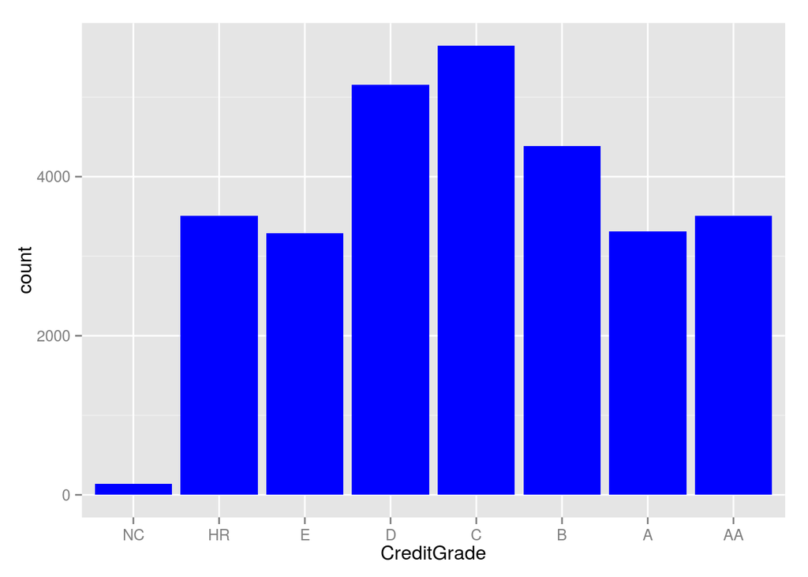

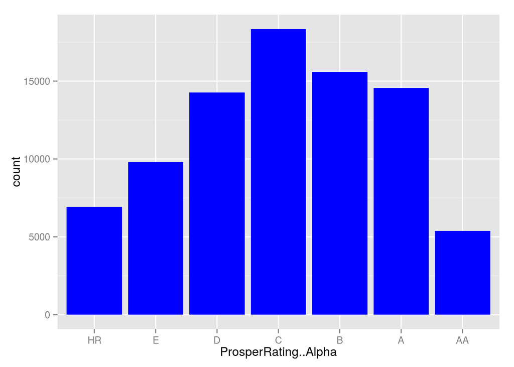

Prosper is growing rapidly, so the majority of loans have LoanStatus equal to ‘Current’. There are a number of categories that apply to active loans that are PastDue. ‘Cancelled’ loans are those rejected by Prosper because initial identity verification or credit checks uncover problems.

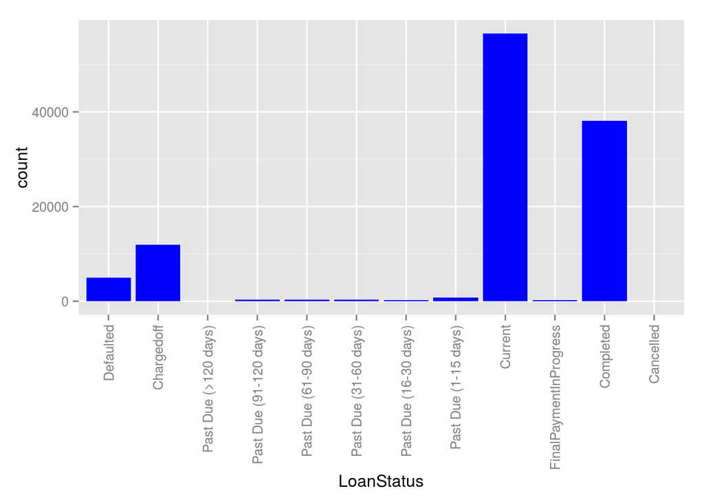

The analysis done here ignores the majority of the data because it focuses on inactive loans. That is, loans with LoanStatus values ‘Completed’, ‘Chargedoff’ or ‘Defaulted’.

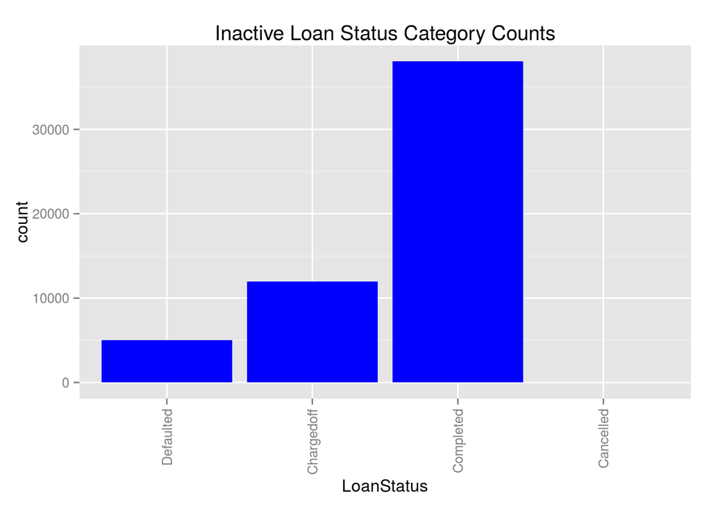

Also, notice the growth in Prosper’s loan portfolio in 2013 and 2014. Most of the loans in the data set are current and were originated in this time span.

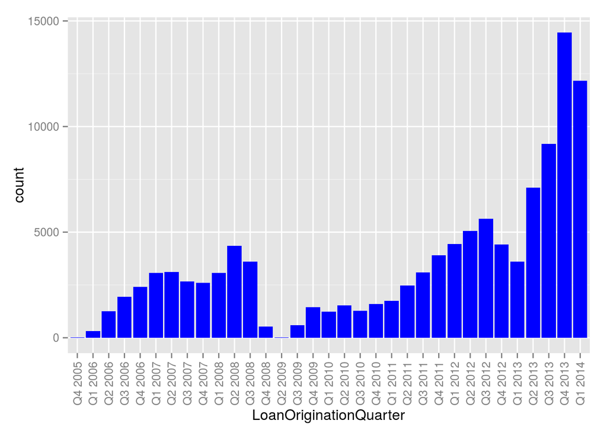

#### Integer variables

CreditScoreRangeLower and CreditScoreRangeUpper are the result of pulling credit reports from multiple credit reporting agencies. They are highly correlated, so only CreditScoreRangeUpper is used by the model fit that is output of this analysis. The distribution of this variable is reasonably close to the coveted Gaussian distribution.

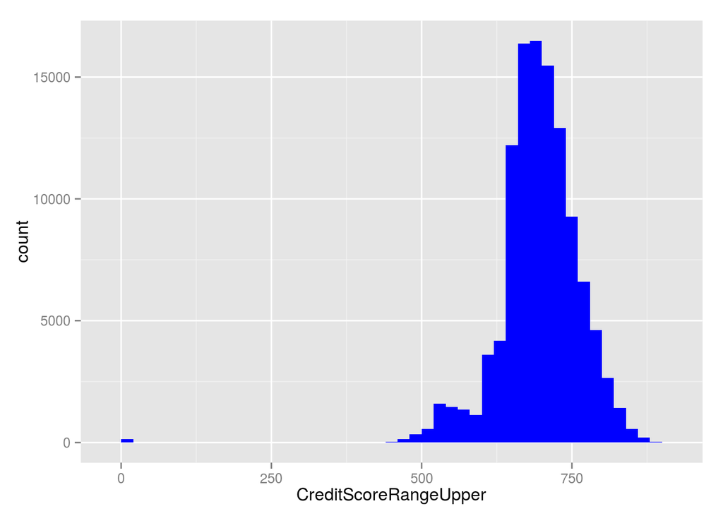

EmploymentStatusDuration, CurrentCreditLines, OpenCreditLines, TotalCreditLinespast7years, OpenRevolvingAccounts are all pulled from borrowers’ credit reports. The columns InquiriesLast6Months and TotalInquiries are the number of requests for that credit report.

CurrentDelinquencies, DelinquenciesLast7Years, PublicRecordsLast10Years, PublicRecordsLast12Months are obtained by pulling borrowers’ credit reports. These relate to problems paying off previous loans and previous declarations of bankruptcy.

TotalTrades and TradesOpenedLast6Months record credit card activity.

LoanOriginalAmount is used in the calculation of the ActualYield for a loan. It is also used in the calculation of one component of the model used to predict loan chargeoffs.

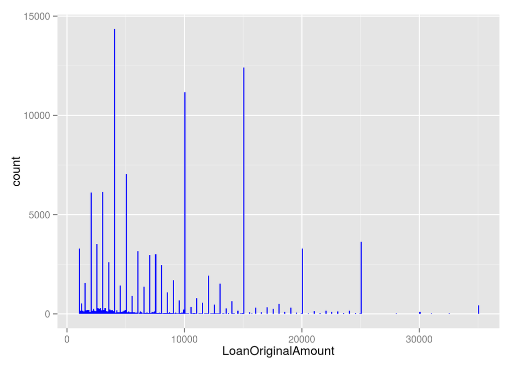

#### Numeric variables

Numeric variables tend to be of four types: those that come from the borrowers’ credit report, those that record the borrowers’ history with previous Prosper loans, those that describe the loan at the time of its origination, and those that track the performance of the loan.

Credit report columns include OpenRevolvingMonthlyPayment, AmountDelinquent, BankcardUtilization, AvailableBankcardCredit, TradesNeverDelinquent..percentage., DebtToIncomeRatio, and StatedMonthlyIncome.

The Prosper loan history columns are ProsperPrincipalBorrowed and ProsperPrincipalOutstanding.

Most of these are not populated enough or are not predictive of loan default, so most are not used in this statistical analysis. The exception is StatedMonthlyIncome which is used in a synthetic variable SqrtIncomeLoanAmountRatio.

StatedMonthlyIncome has an unusual distribution. It has a very long tail corresonding to a very high monthly income.

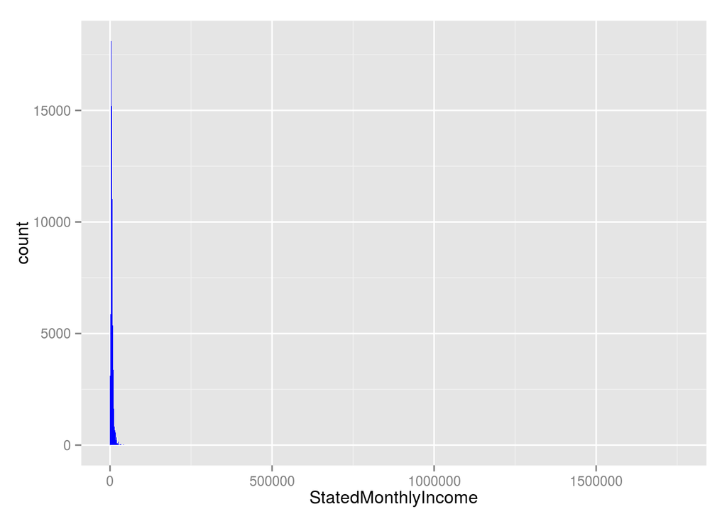

The part of the distribution of StatedMonthlyIncome that is not in the high income tail is spiky because loans that are multiples of 100 dollars are more common than the alternative. The binwidth used in the histogram below is chosen to suppress this spikiness. The smoothed histogram looks like a Poisson distribution that is trending toward Gaussian goodness.

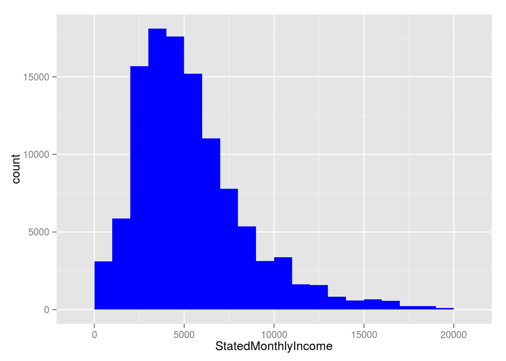

The columns that describe the loan at the time of origination are BorrowerAPR, BorrowerRate, LenderYield, EstimatedEffectiveYield, EstimatedLoss, EstimatedReturn, and MonthlyLoanPayment. InvestmentFromFriendsAmount is fixed at loan origination time; its distribution is too close to a delta function at the origin to use in my analyses.

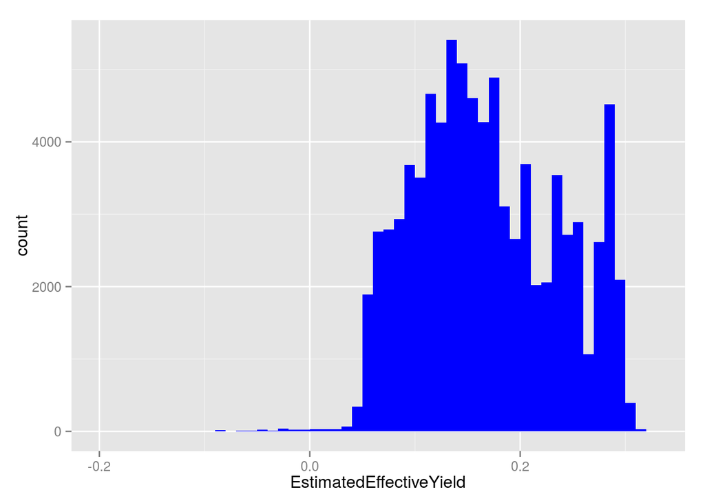

The computation of ActualYield, a focus of the analyses made here, makes use of the columns LP_CustomerPayments, LP_ServiceFees, LP_NonPrincipalRecoverypayments, and LoanOriginalAmount. These belong to a set of columns that track the loan performance from the time of origination to the day at which the loan completes or defaults.

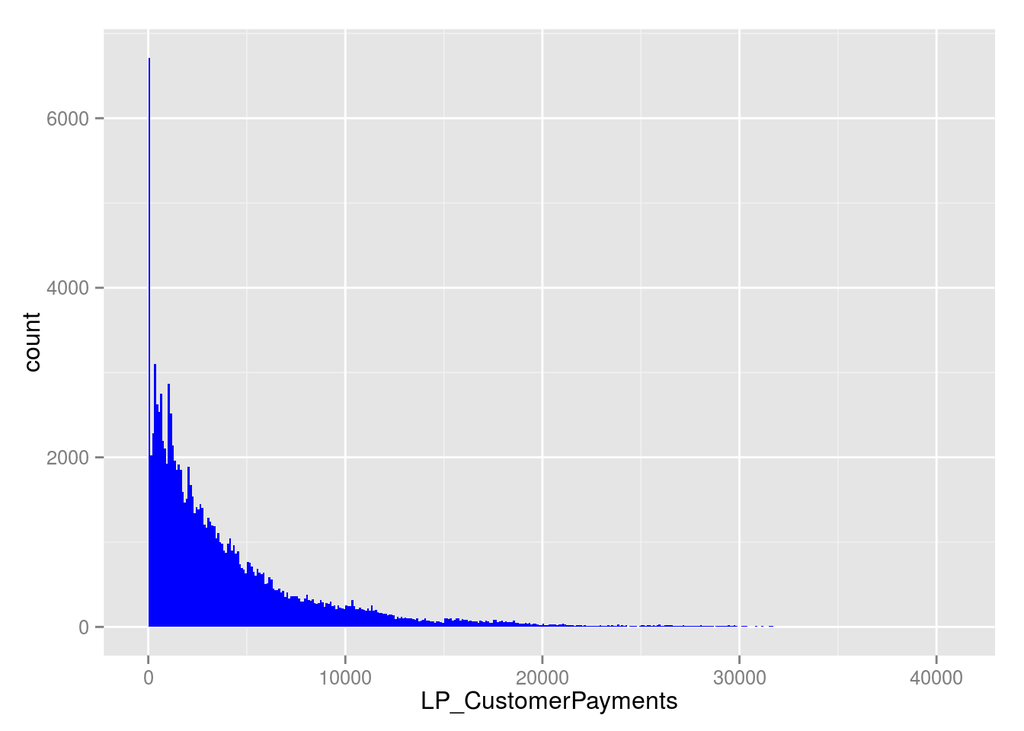

Service fees are a cost imposed by Prosper.

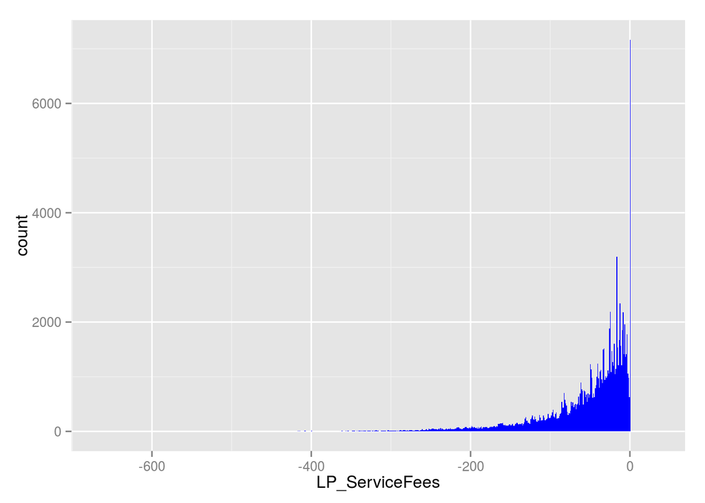

Principal recovery payments are made by borrowers on charged-offs as part of a debt settlement.

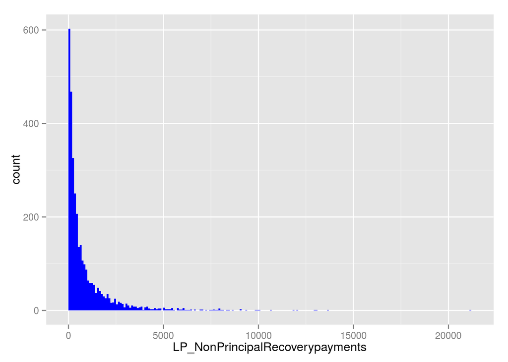

#### Synthetic

Much of the analysis concerns the difference between EstimatedEffectiveYield and the ActualYield obtained by completed loans.

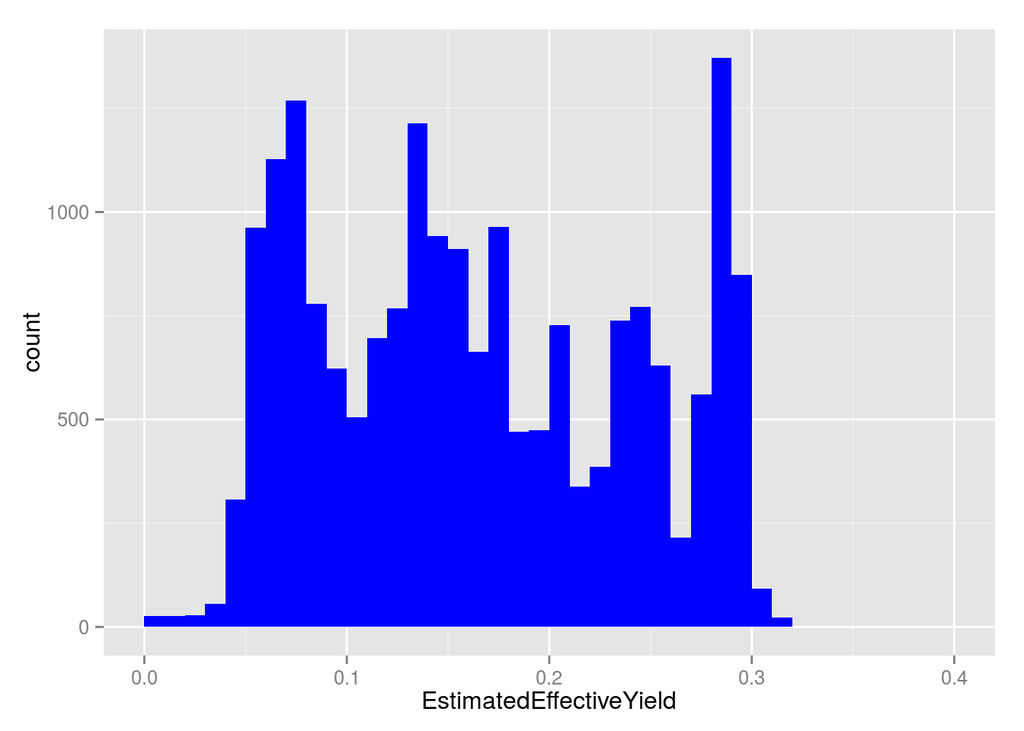

The histogram of the ActualYield is simpler but similar in form to that for EffectiveYield. It is displaced well to the left (lower yields) than the estimated yield provided by Prosper. This is evidence that, at least by some definition of yield, the yield estimates quoted by Prosper are higher than the actual yield.

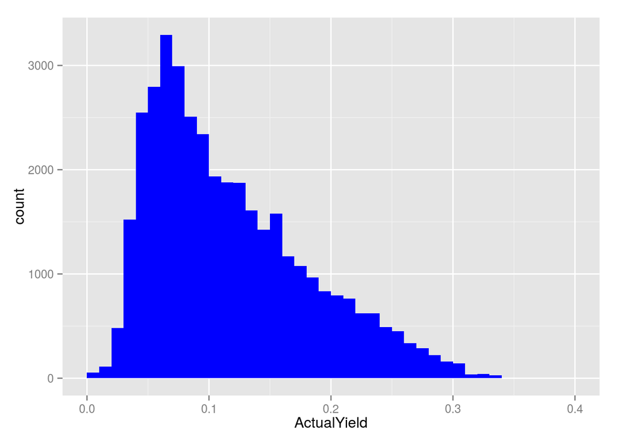

The square root of the ratio of StatedMonthlyIncome and LoanOriginationAmount is used in a model to explain loan defaults. This ratio rather than its reciprocal was used to avoid generating NaNs that the R function glm choked on. The square root is employed to make the distribution look more Gaussian. A ratio was used in the belief the market should create a situation where size should not help in predicting loan defaults.

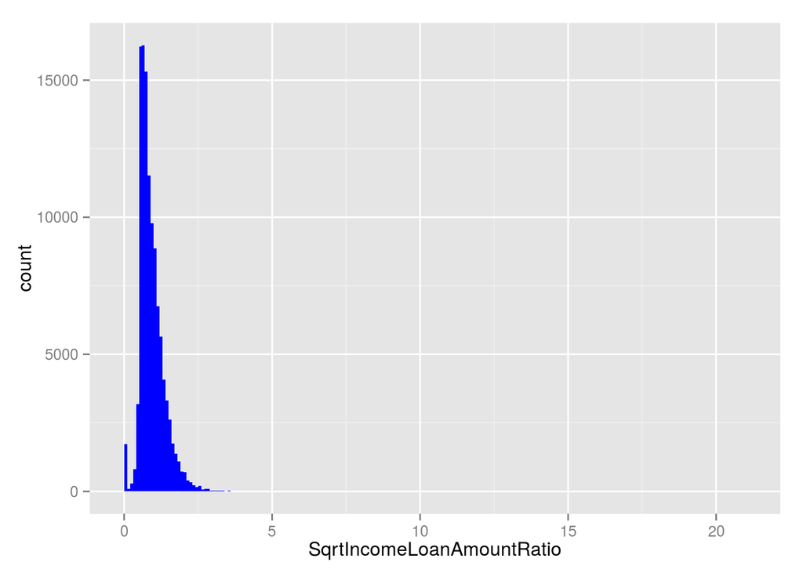

# Univariate Analysis

### What is the structure of your dataset?

Some of the columns are identifiers. The values of are not related to anything else. One of these of type int: ListingNumber. The others are of type character (hex strings): GroupKey,ListingKey, LoanKey, and MemberKey.

Three of the columns are logical: IsBorrowerHomeowner, CurrentlyInGroup, IncomeVerifiable. All three are used to provide some of the information for a borrower’s credit profile.

Five of the columns are Dates: ListingCreationDate, ClosedDate, DateCreditPulled, FirstRecordedCreditLine, LoanOriginationDate. ListingCreationDate, DateCreditPulled, LoanOriginationDate, and ClosedDate mark successive transitions in the lifecycle of a loan. FirstRecordedCreditLine is part of the borrower’s credit profile.

CreditGrade is a factor column. It has 9 levels: “”, “A”, “AA”, “B”, “C”, “D”, “E”, “HR”, “NC”. “NC” means no credit history. The null-string value is there for loans made 2009 and afterwards. I ordered these from low to high as follows “NC” < “HR” < “E” < “D” < “C” < “B” < “A” < “AA” < “”.

ProsperRating..Alpha is a factor column that has 8 levels: “A”, “AA”, “B”, “C”, “D”, “E”, “HR”, “”. I ordered these from low to high as follows: “HR” < “E” < “D” < “C” < “B” < “A” < “AA” < “”. ProsperRating..numeric. associates “HR” with 1, “E” with 2, and so on up to “AA” which maps to 7. “” maps to NA.

LoanStatus is a factor column with 12 levels that track the life cycle of a loan. With “Cancelled” placed last and from least desirable to most desirable the values are “Defaulted”, “Chartedoff”, “Past Due (>120 days)”, “Past Due (91-120 days)”, “Past Due (61-90 days)”, “Past Due (31-60 days)”, “Past Due (16-30 days)”, “Past Due (1-15 days)”, “Current”, “FinalPaymentInProgress”, “Completed”, “Cancelled”.

BorrowerState is a factor column with 52 levels. These correspond to the states in the United States plus “DC” for the District of Columbia plus “” for borrowers not in a state.

Occupation is a factor column with 68 levels. The values are filled in by the borrower when applying for a listing. Values are Accountant/CPA“,”Administrative Assistant“, and so on.”" is the null assignment.

EmploymentStatus is a factor column. Values are “”, “Employed”, “Full-time”, “Not available”, “Not employed”,“Other”,“Part-time”,“Retired”,“Self-employed”. Unordered.

IncomeRange is a factor column that categorizes borrower income. The values are as follows: “$0”, “$100,000+”, “$1-24,999”, “$25,000-49,999”, “$50,000-74,999”, “$75,000-99,999”, “Not displayed”, and “Not employed”. I ordered these as follows: “Not employed” < “$0” < “$1-24,999” < “$25,000-49,999” < “50,000-74,999” < “$75,000-99,999” < “$100,000+” < “Not displayed”.

LoanOriginationQuarter is a factor column with 33 levels. Examples are “Q1 2006”, “Q2 2006”, and so on. I ordered these in time order from earliest to latest.

Columns that are filled in by the time the credit reports are pulled are used to provide a credit report profile to investors. Those not already mentioned include EmploymentStatusDuration, CreditScoreRangeLower, CreditScoreRangeUpper, FirstRecordedCreditLine, CurrentCreditLines, OpenCreditLines, TotalCreditLinespast7years, OpenRevolvingAccounts, OpenRevolvingMonthlyPayment, InquiriesLast6Months, TotalInquiries, CurrentDelinquencies, AmountDelinquent, PublicRecordsLast10Years, PublicRecordsLast12Months, RevolvingCreditBalance, BankcardUtilization, AvailableBankcardCredit, TotalTrades, TradesNeverDelinquent..percentage, TradesOpenedLast6Months, DebtToIncomeRatio, ;IncomeRange, IncomeVerified, and StatedMonthlyIncome.

A second set of columns describe the credit-worthiness of the borrower in terms of past history with Prosper loans: TotalProsperLoans, TotalProsperPaymentsBilled, OnTimeProsperPayments, ProsperPaymentsLessThanOneMonthLate, ProsperPaymentsOneMonthPlusLate, ProsperPrincipalBorrowed, and ProsperPrincipalOutstanding. For loans prior to September 2013: ScorexChangeAtTimeOfListing. There are not enough repeat borrowers to make these very interesting.

Some 16 columns are used to track the current financial state of a loan: LoanCurrenDaysDelinquent, LoanFirstDefaultedCycleNumber, LoanMonthsSinceOrigination, LoanNumber, LoanOriginalAmount, LoanOriginationDate, MonthlyLoanPayment, LP_CustomerPayments, LP_CustomerPrincipalPayments, LP_InterestandFees, LP_ServiceFees, LP_CollectionFees, LP_GrossPrincipalLoss, LP_NetPrincipalLoss, and LP_NonPrincipalRecoverypayments.

Recommendations, InvestmentFromFriendsCount, InvestmentFromFriendsAmount, and Investors track listing properties before the loan is originated.

BorrowerAPR is the annualized interest rate on the loan. BorrowerRate is the interest rate on the loan, which is compounded daily. The LenderYield is the BorrowerRate minus a borrower’s fee (1%).

EstimatedEffectiveYield is equal to the BorrowerRate minus a servicing fee rate minus the estimated uncollected interest on chargeoffs plus estimated collected late fees on chargeoffs.

EstimatedLoss is the probability that a loan will become a chargeoff.

EstimatedReturn is equal to EstimatedEffectiveYield minus EstimatedLoss.

### What are the main feature(s) of interest in your dataset?

My goals were to (1) estimate the actual yield for the different ProsperRatings and compare these against the EstimatedEffectiveYield offered by Prosper, and (2) find variables that predict loan chargeoff and eventual default.

The main features of interest for the first goal are LoanStatus, EstimatedEffectiveYield, and the synthetic column ActualYield.

The columns for the second goal that were actually used are: CreditScoreRangeUpper, OpenRevolvingAccounts, InquiriesLast6Months, the synthetic column SqrtIncomeLoanAmountRatio, TotalCreditLinespast7years, CurrentDelinquencies, DelinquenciesLast7Years, and OpenRevolvingMonthlyPayment.

### What other features in the dataset do you think will help support your investigation into your feature(s) of interest?

ActualYield is calculated from ClosedDate, LoanOriginationDate, LP_CustomerPayments, LP_ServiceFees, LP_NonPrincipalRecoverypayments, and LoanOriginalAmount. The analysis compares the actual yield with the EstimatedEffectiveYield offered by Prosper.

ProsperRating..Alpha was used to understand the EstimatedEffectiveYield and ActualYield.

I performed a logistic regression and used the coefficients to construct a synthetic column: GLMFit7. There used to be GLMFit columns that were used to eliminate columns that relate to credit worthiness but failed to have predictive value.

### Did you create any new variables from existing variables in the dataset?

LoansOriginationQuarter is a factor column. A typical entry value is ‘Q1 2011’. This column was used to generate two new integer-valued columns: Quarter and Year.

CompleteDays, defined for completed loans and chargeoffs, was calculated by subtracting LoanOriginationDate from ClosedDate and then converting the result to a numeric.

ActualYield, defined for completed loans and chargeoffs, was calculated using the interest rate formula. Assuming compounding by day, the formula for this is $ActualYield = 365 * (((LP\_CustomerPayments + LP\_ServiceFees + LP\_NonPrincipalRecoverypayments)$ $/LoanOriginalAmount)^{(1.0/CompleteDays)}-1.0)$. This R formula has bad numerical properties, so it was rewritten as $ActualYield = 365 * (exp(log((LP\_CustomerPayments + LP\_ServiceFees + LP\_NonPrincipalRecoverypayments)$ $/LoanOriginalAmount)*{(1.0/CompleteDays)})-1.0)$. The assumption that interest is compounded daily comes from footnotes in one of Prosper’s web pages.

As noted above, I performed a logistic regression and used the coefficients to construct a synthetic column: GLMFit7. $GLMFit7 = -3.9950 + 0.008386 * CreditScoreRangeUpper + 0.02125 * OpenRevolvingAccounts -$ $0.1209 * InquiriesLast6Months + 1.013 * SqrtIncomeLoanAmountRatio -$ $0.009103 * TotalCreditLinespast7years - 0.1113 * CurrentDelinquencies +$ $0.009992 * DelinquenciesLast7Years - 0.000507 * OpenRevolvingMonthlyPayment$

The feature Completed was added to the subset of the data with LoanStatus values ‘Completed’, ‘Chargedoff’, or ‘Defaulted’. This is a boolean used in the logistic regression that calculated the coefficients used to construct GLMFit7 (and other fits not mentioned here).

### Of the features you investigated, were there any unusual distributions? Did you perform any operations on the data to tidy, adjust, or change the form of the data? If so, why did you do this?

I investigated all of the features that have distributions, even those not directly relevant to the analysis. There were a lot of interesting non-Gaussian distributions, some irregular. In order of appearance in the R environment:

| Feature | Distribution | Comments |
| --- | --- | --- |
| BorrowerAPR | Gaussian | Spikes superimposed |
| BorrowerRate | Gaussian | Spikes superimposed |
| LenderYield | Gaussian | Spikes superimposed |
| EstimatedEffectiveYield | Poisson | Spikes superimposed |
| EstimatedLoss | Poisson | Spikes superimposed |
| EstimatedReturn | Gaussian |  |
| ProsperScore | Gaussian |  |
| EmploymentStatusDuration | Exponential |  |
| CreditScoreRangeLower | Gaussian |  |
| CreditScoreRangeUpper | Gaussian |  |
| CurrentCreditLines | Poisson |  |
| OpenCreditLines | Poisson |  |
| TotalCreditLinespast7years | Poisson | Excess at origin |
| OpenRevolvingAccounts | Poisson | Excess at origin |
| InquiriesLast6Months | Exponential |  |
| TotalInquiries | Exponential |  |
| CurrentDelinquencies | Exponential |  |
| DelinquenciesLast7Years | Spike at origin + Exponential |  |
| PublicRecordsLast10Years | Exponential |  |
| PublicRecordsLast12Months | Delta function |  |
| OpenRevolvingMonthlyPayment | Exponential |  |
| AmountDelinquent | Spike at origin + Exponential |  |
| BankcardUtilization | Irregular |  |
| AvailableBankcardCredit | Exponential |  |
| TotalTrades | Poisson |  |
| TradesOpenedLast6Months | Exponential |  |
| TradesNeverDelinquent..percentage | Beta | Peaked near 1.0 |
| DebtToIncomeRatio | Gaussian | Long, non-Gaussian tail. |
| StatedMonthlyIncome | Gaussian | Many superposed spikes. Long, non-Gaussian tail. |
| LoanCurrentDaysDelinquent | Spike at origin + Irregular, multimodal |  |
| LoanFirstDefaultedCycleNumber | Poisson | Gap at cycles 2,3, and 4 |
| LoanOriginalAmount | Gaussian |  |
| MonthlyLoanPayment | Irregular | Multimodal with large spikes |
| LP_CustomerPayments | Spike at origin + exponential |  |
| LP_CustomerPrincipalPayments | Exponential | Many superposed spikes |
| LP_InterestAndFees | Spike at origin + exponential | Chargedoffs contribute an exponential |
| LP_ServiceFees | Spike at origin + exponential | Chargedoffs contribute an exponential |
| LP_CollectionFees | Spike at origin + exponential | Chargedoffs contribute an exponential |
| LP_GrossPrincipalLoss | Poisson | Excess near origin |
| LP_NetPrincipalLoss | Poisson | Excess near origin |
| LP_NonPrincipalRecoveryPayments | Exponential |  |
| Recommendations | Spike at origin + exponential |  |
| InvestmentFromFriendsCount | Spike at origin + exponential |  |
| InvestmentFromFriendsAmount | Spike at origin + exponential |  |
| SqrtIncomeLoanAmountRatio | Poisson |  |

# Bivariate Plots

### Actual Yield and EstimatedEffectiveYield

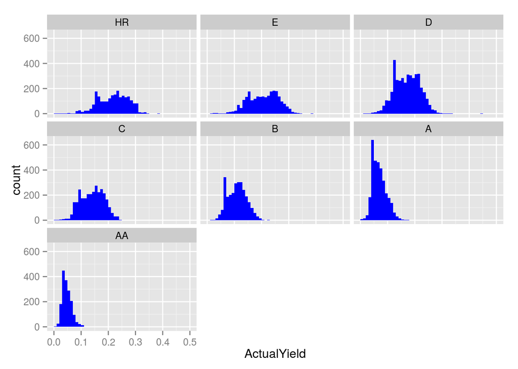

Actual yields are usually less than the estimated effective yields quoted by Prosper at the time of origination.

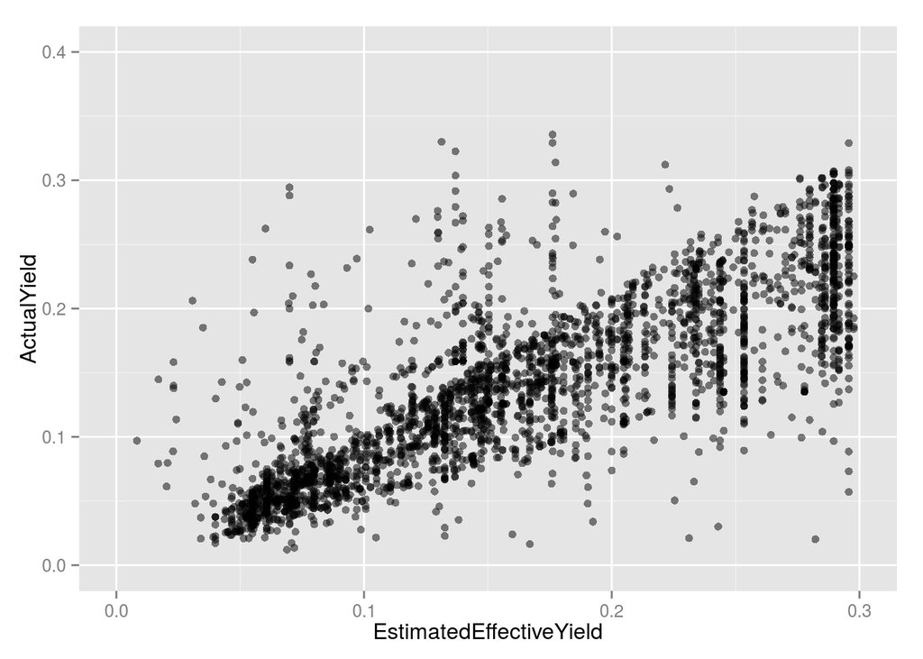

There is evidence that the larger economy had a significant impact on yields. Yields, estimated and actual both shifted upwards in 2011. The shift in EstimatedEffectiveYield reflects Prosper’s view of the economic environment.

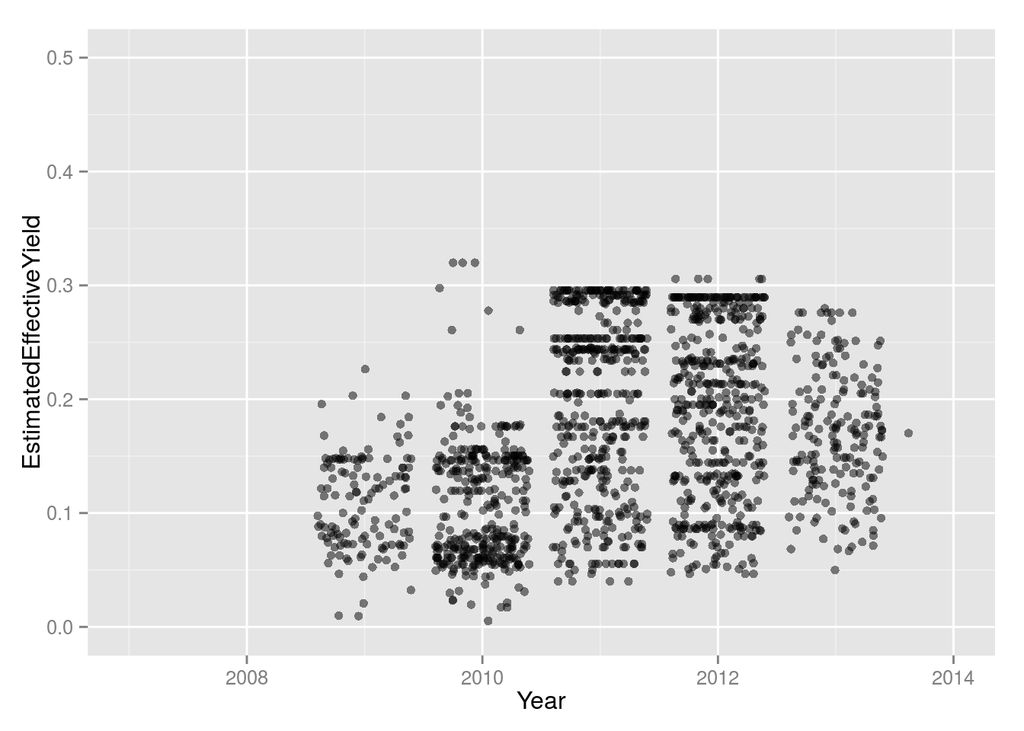

ActualYields nudged upwards in 2011, reflecting a change in interest rates from two or three years before. The effect is less dramatic than that seen in EstimatedEffectiveYield because loans are paid off in roughly two years and because there is a spread of loan terms.

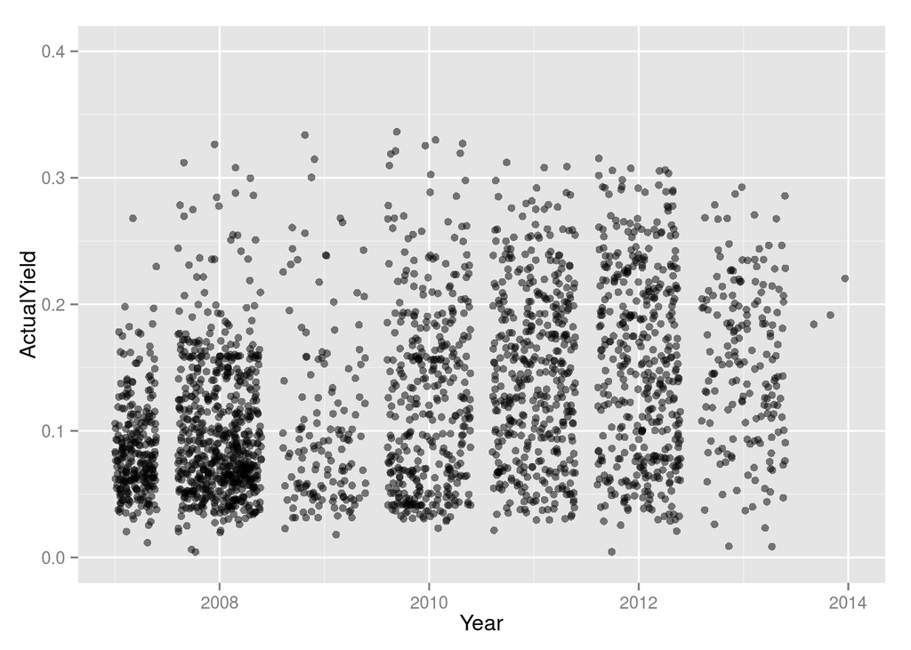

### Credit Rating Dependence or Independence

What variables might predict loan defaults. Credit scores claim to do this. Are there other variables?

The range of credit scores reported out of credit agencies are recorded in CreditScoreRangeLower and CreditScoreRangeUpper. These are highly correlated.

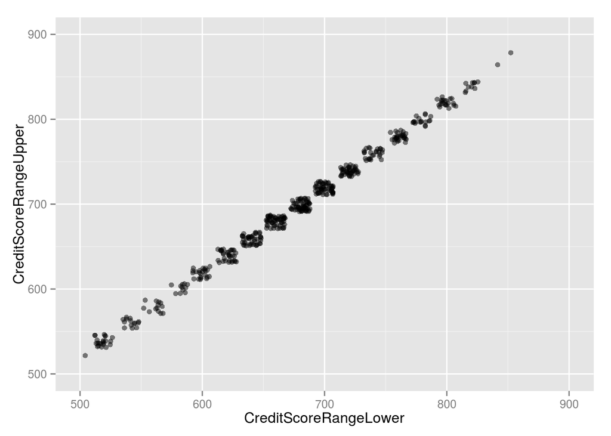

The remaining bivariate scattergrams looks only at loans that have status Completed, Chargedoff, or Defaulted. Active loans are of no interest in an analysis that tries to find predictors of default.

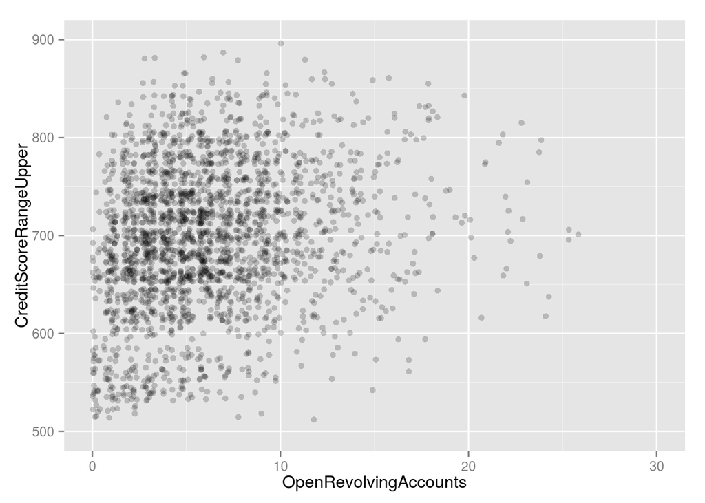

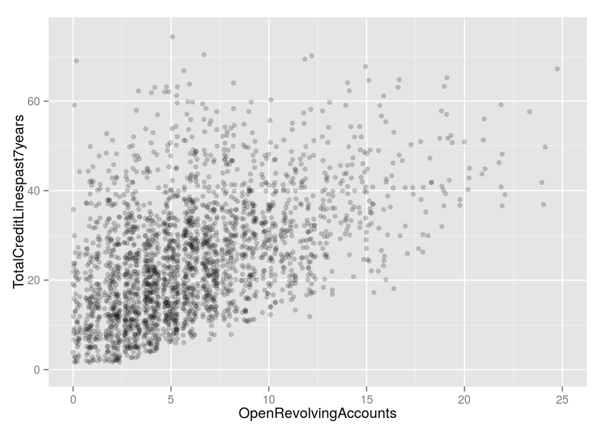

An even more weakly correlated pair of columns is that of TotalCreditLinespast7years and SqrtIncomeLoanAmountRatio.

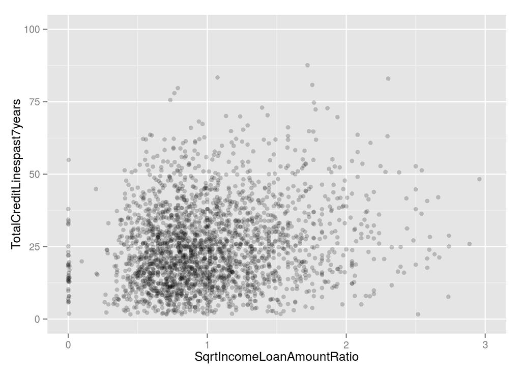

TotalCreditLinespast7years and CurrentDelinquencies have a lack of correlation that is more typical of the pairs of variables in this study. This one is of more interesting than most, but the reason is in the MultiVariate Plots section (see below).

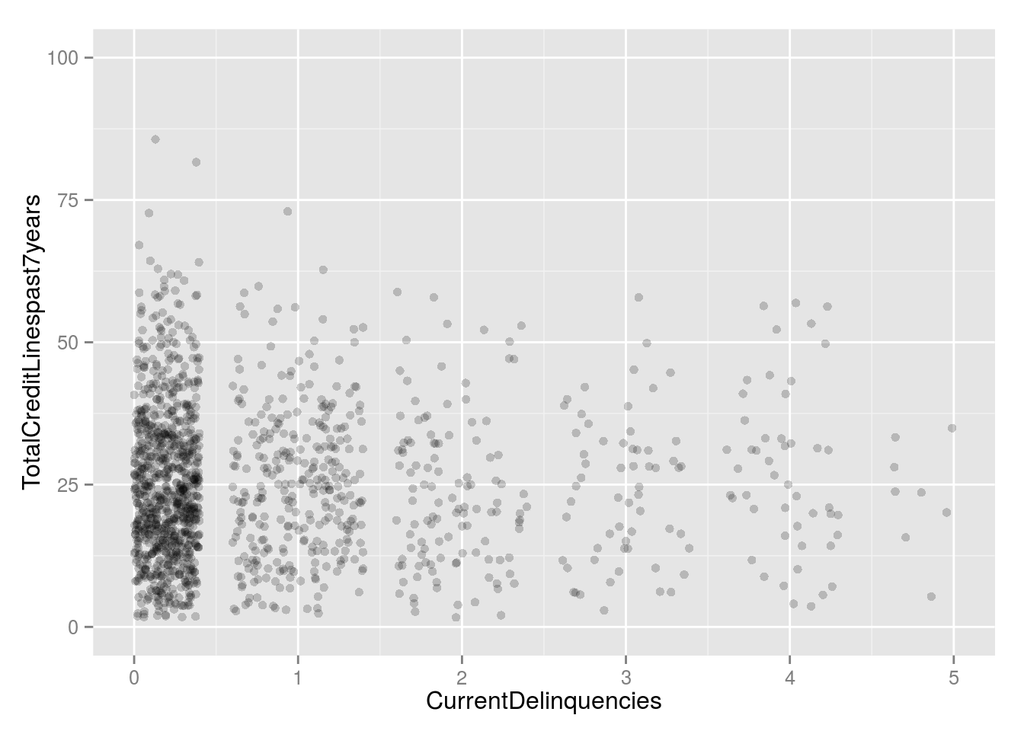

The logistic model fit (discussed near the end) correlates strongly with credit score. This is not surprising, because credit score is a component of the model.

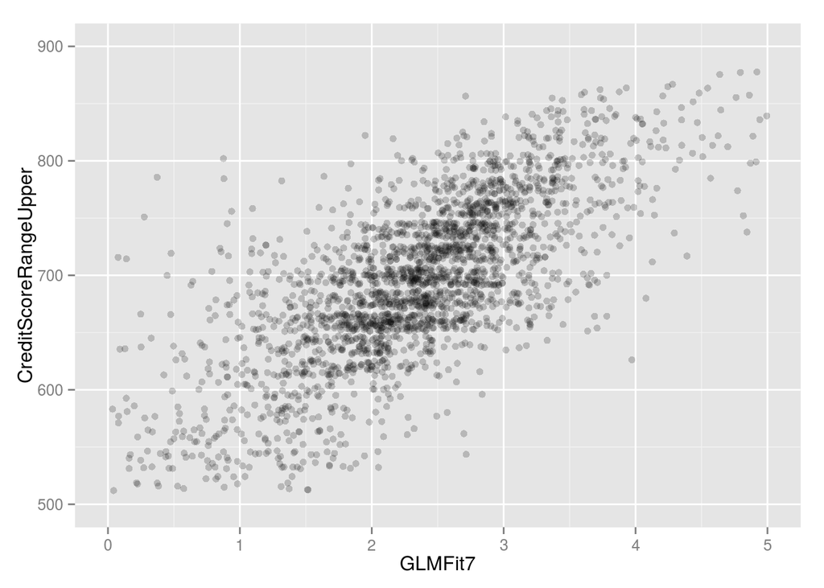

# Bivariate Analysis

### Talk about some of the relationships you observed in this part of the investigation. How did the feature(s) of interest vary with other features in the dataset?

EstimatedEffectiveYield and ActualYield were correlated. The correlation is not as high as investors might like. EstimatedEffectiveYield is almost always higher than ActualYield. A typical loan yield is about 2/3 the amount estimated by Prosper at the time the loan originates. This conclusion is based only on the performance of loans that complete; including chargeoffs would decrease the performance even more.

The logistic model fit (discussed near the end) correlates with credit score. This is good news because it is the point of the analysis. Also, it is not surprising, as credit score is one of the variables in the fit’s formula.

None of the variables that came with the data set that one would normally associate with credit worthiness correlated very well with the credit scores.

### Did you observe any interesting relationships between the other features (not the main feature(s) of interest)?

For variables that might predict loan default? No! The correlations were between variables that one would expect to be highly correlated. One of the main conclusions that can be drawn is that no single factor known to be used in credit score calculations significantly correlates with credit scores. The variables that were chosen to explain loan default were not highly correlated with each other.

### What was the strongest relationship you found?

CreditScoreRangeLower and CreditScoreRangeUpper. The relationship between CrediScoreRangeUpper and GLMFit7 is also strong.

# Multivariate Plots

### ActualYield

As already noted, ActualYield and EstimatedEffectiveYield are positively correlated.

There are actually two triangular regions in the scatterplot. The fainter one is displaced by 10% upwards from the one that starts near the origin. This is probably a reflection of opportunities available to those brave enough to loan money in 2009 when the banking sector was closed down.

The 2008-2009 ghost is evidence that the relationship between EstimatedEffectiveYield, the predicted risk, and ActualYield, the actual return, has been more or less time-independent since 2011.

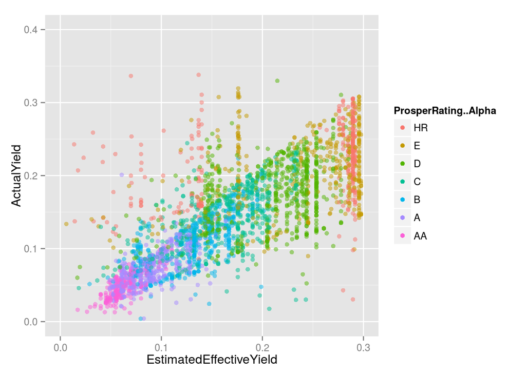

When plotted as a function of time, the ActualYield values observed separate into bands that correspond to the ratings that prosper offered before the loan was originated. Note the upward shift in 2011, reflective of conditions in years 2008 and 2009.

The color banding in the scatterplot corresponds to Prosper’s credit rating. One unexpected feature is red spot in 2012 with yields > 0.25 that corresponds to high risk (HR) loan activity.

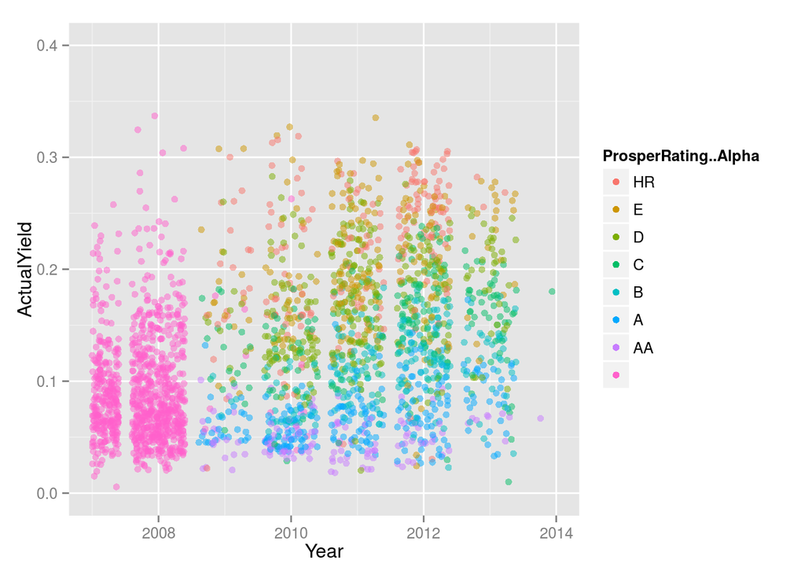

### Credit Worthiness Over Time

CreditScoreRangeUpper predicted chargedoff and default statuses reasonably well.

There are outliers for which the credit score is 0. This is impossible in the real world and must be assignments made Prosper to fill in for missing data.

The different spreads in credit scores in 2009 is caused by a change in banking practice on the part of Prosper. They switched credit rating methodology in that year.

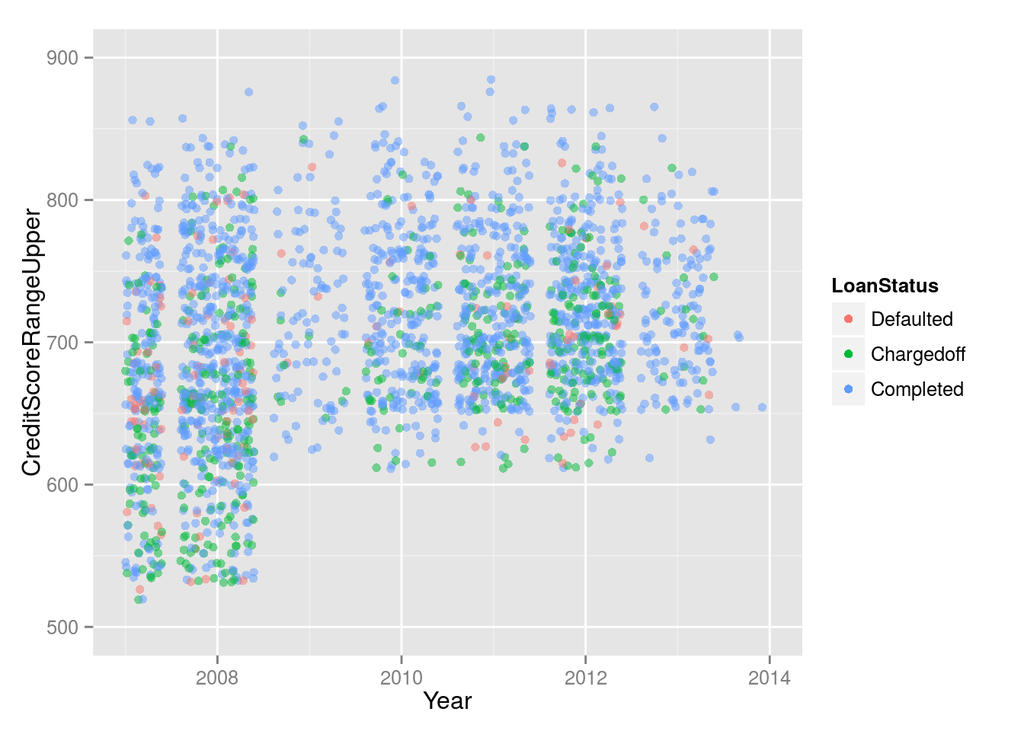